# Beautiful Music: Symbolic Generation on the Nottingham Folk Corpus

**Tasks attempted (2 of 4):**

1. **Task 1 — Symbolic, *unconditioned* generation.** Learn an unconditional distribution $p(x)$ over folk melodies in ABC notation and sample new tunes from it.
2. **Task 2 — Symbolic, *conditioned* generation.** Given an input melody, detect its *style* with a trained classifier and generate a brand-new continuation conditioned on that detected style **and** the opening bars of the input.

Both tasks share one dataset (Nottingham, in ABC notation) and one output representation (ABC text → MIDI), which lets us reuse data processing and evaluation machinery across them.

**How to read this notebook.** Each task is laid out in the four graded sections — *Data*, *Modeling*, *Evaluation*, *Related work* — and the first three are each broken into **Context / Discussion / Code** so every rubric item is easy to locate. All numbers and plots below are the *actual* artifacts produced by our `medium` Kaggle (T4 GPU) runs; the heavy training code lives in `code/task1.../run_experiments.py` and `code/task2.../run_task2.py` and is excerpted inline so the analysis can be followed without executing anything.

```python
# Lightweight setup -- only used to render the result tables and plots that follow.
import pandas as pd
from IPython.display import Image, display
pd.set_option("display.width", 160)
pd.set_option("display.max_columns", 40)
```

# TASK 1 — Symbolic, Unconditioned Generation

**Goal.** Train a model of $p(x)$ over Nottingham folk melodies represented as ABC-notation text, then sample novel melodies and render them to MIDI. We train several models spanning a complexity spectrum — a **character N-gram Markov chain**, a **character-level LSTM**, and a **fine-tuned GPT-2** — and additionally run two **pretrained ABC-native Transformers** (*TunesFormer*, *MelodyT5*) as strong reference points. The real held-out test set is treated as the *oracle* distribution.

## 1.1 Data — Context

**Source.** The **Nottingham Music Database** is a long-standing collection of ~1,000+ British and American folk tunes (jigs, reels, hornpipes, waltzes, etc.). We use the cleaned **JukeDeck** GitHub release (`jukedeck/nottingham-dataset`), which stores each tune in **ABC notation** — a compact text format where a header (`X:` index, `T:` title, `M:` meter, `L:` unit note length, `K:` key) precedes a body of note tokens, bar lines `|`, and repeats.

**Why this dataset.** It is *small, clean, monophonic-friendly, and text-native*, which makes it ideal for comparing model families on a single GPU: an ABC tune is literally a short string, so the same corpus supports an N-gram, an RNN, and a Transformer language model with no change of representation. It is also a classic symbolic-music benchmark (used by Boulanger-Lewandowski et al., 2012), giving us historical baselines to discuss.

## 1.2 Data — Discussion (pre-processing)

Our pre-processing pipeline (`ensure_nottingham_data`, `make_melody_only`) does the following:

- **Parse** each `.abc` file into individual tunes by splitting on the `X:` index header.
- **Melody-only view.** We strip accompaniment chord symbols (text in quotes, e.g. `"Gm"`) with `strip_chords`, collapse whitespace, and **normalize the header** so only musically meaningful fields (`X, T, M, L, K`) are kept (`normalize_headers`). This focuses the language model on melodic content rather than chord annotations.
- **Document separator.** Tunes are concatenated with an `<|endoftext|>` delimiter so the models learn where tunes begin and end (important for sampling complete tunes).
- **Stratified split.** We split **per subset** (jigs, reels, …) into **80/10/10 train/val/test** with a fixed seed (42), so every style is represented in all three splits and the test set is a fair oracle.

## 1.3 Data — Code & statistics

Below is the real header-normalisation step that defines our "melody-only" representation, followed by the **pitch-class histogram of the real test set** (our oracle), which we later use as the reference distribution for the *Overlapping Area* metric.

```
# code/task1_unconditional_generation/run_experiments.py
def strip_chords(abc_str: str) -> str:
    return re.sub(r'"[^"]*"', "", abc_str)            # remove "Gm", "D7", ... chord symbols

def normalize_headers(abc_str, keep=("M", "L", "K", "X", "T")):
    # keep only musically meaningful header fields; everything after K: is the tune body
    ...

def make_melody_only(abc_str: str) -> str:
    cleaned = strip_chords(abc_str)
    cleaned = re.sub(r"  +", " ", cleaned)
    return normalize_headers(cleaned)
```

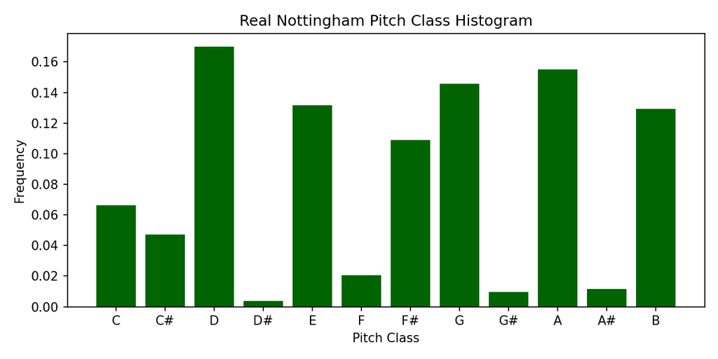

```
Oracle descriptive statistics (per-tune means):
```

|  | Real test set (oracle) |
| --- | --- |
| pitch_count_mean | 21.051 |
| pch_entropy_mean | 1.892 |
| pitch_range_mean | 35.184 |
| note_count_mean | 323.857 |
| scale_consistency_mean | 0.985 |

```python
# Real test-set (oracle) pitch-class usage -- the reference distribution for our OA metric.
display(Image("real_pch.png"))

# Summary statistics of the real test set (the oracle row of our Task 1 metrics).
t1 = pd.read_csv("t1_metrics.csv")
oracle = t1[t1["model"].str.contains("Oracle")][
    ["pitch_count_mean", "pch_entropy_mean", "pitch_range_mean",
     "note_count_mean", "scale_consistency_mean"]
].round(3)
oracle.index = ["Real test set (oracle)"]
print("Oracle descriptive statistics (per-tune means):")
oracle.T
```

## 2.1 Modeling — Context

**ML formulation.** We treat a tune as a sequence of tokens $x_{1:T}$ and train an **autoregressive language model** that factorises $p(x_{1:T}) = \prod_t p(x_t \mid x_{<t})$.

- **Inputs / outputs:** input is the prefix $x_{<t}$; output is a categorical distribution over the next token $x_t$ (characters for Markov/LSTM, BPE sub-words for GPT-2).
- **Objective:** minimise the average **negative log-likelihood (cross-entropy)** of held-out tokens — equivalently, minimise **perplexity**.
- **Sampling:** new tunes are generated by temperature-controlled ancestral sampling, then the ABC string is cleaned and converted to MIDI.

**Models appropriate for the task,** in order of capacity: a **Markov chain** (counts of which character follows a fixed-length context) is the trivial-but-real probabilistic baseline; a **character LSTM** adds unbounded context through a recurrent hidden state; **GPT-2 fine-tuning** brings a pretrained sub-word Transformer with long-range self-attention. We add **TunesFormer** and **MelodyT5** as pretrained ABC-native references.

## 2.2 Modeling — Discussion (advantages / disadvantages)

| Model | Pros | Cons |
| --- | --- | --- |
| **Markov (char N-gram)** | Trivial to fit (just counts); exact NLL; surprisingly strong locally | Fixed context window `k`; no long-range structure; can get stuck / repeat |
| **CharLSTM (from scratch)** | Unbounded context via hidden state; cheap to train; **best held-out NLL/PPL** here | Sequential (slow); weaker at very long-range form than attention |
| **GPT-2 fine-tuned** | Pretrained language prior; long-range attention; high grammar validity | Sub-word tokeniser not music-aware; we don't get a clean per-character NLL; heavier to train |
| **TunesFormer / MelodyT5 (pretrained)** | ABC-native, bar-patching/control codes; strong musical structure | **Not trained by us** — used only as references/oracles, *not* our contribution |

**Honesty note on "training our own weights":** Markov, CharLSTM and the GPT-2 fine-tune are fully fit by us on the Nottingham training split. TunesFormer and MelodyT5 are run from *published* weights and are clearly labelled as pretrained references — they are not claimed as models we trained.